# HW6_B66043

Dzvezdana Arsovska

March 28, 2017

## Exercise 1

Data set HW6_ex1.txt contains two features: x and y. Plot functions y = x, y = 1.5x and y = 2x on the data. Implement and calculate root mean squared error (RMSE) for each of the functions. Describe in few sentences (or make an illustration) about what does RMSE measure? Which of the models describes data the best?

**Solution:**

The Root Mean Squared Error (RMSE) is a measure of how close a fitted line is to data points. The regression line predicts the average y value associated with a given x value.

To construct the RMSE first we need to determine the residuals. Residuals are the difference between the actual values and the predicted values. They can be positive or negative as the predicted value under or over estimates the actual value. Squaring the residuals, averaging the squares, and taking the square root gives us the RMSE.

The RMSE is thus the distance, on average, of a data point from the fitted line, measured along a vertical line.

If we plot the functions y = x, y = 1.5x and y = 2x, we can notice that y = 1.5x seems to describe the data the best since the line best describes the relationship between the dependent variable y and x.

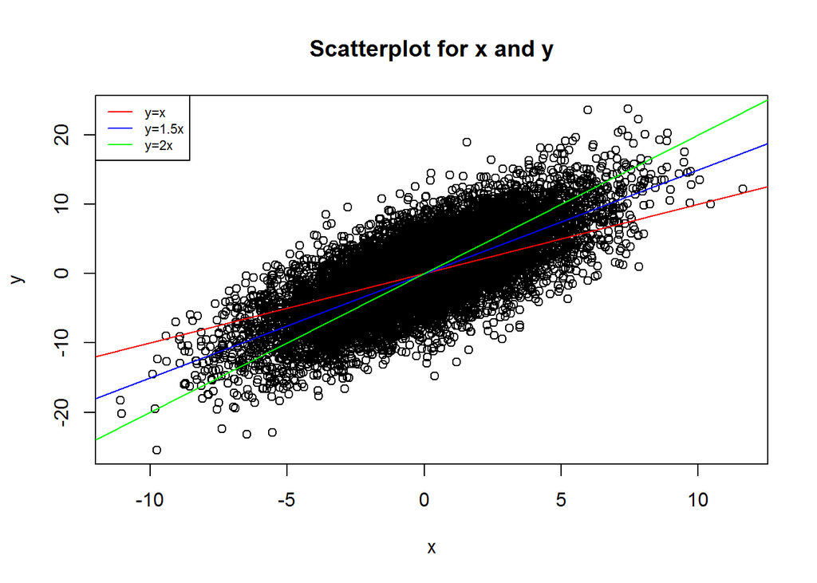

```r
library(data.table)
data_6 <- fread("C:/Users/Arsovska/Desktop/HW6_exercise1-txt.csv")

plot(y ~ x, data = data_6, main = "Scatterplot for x and y")

abline(0, 1, col = "red")
abline(0, 1.5, col = "blue")
abline(0, 2, col = "green")

legend("topleft", legend = c("y=x", "y=1.5x", "y=2x"), col = c("red", "blue",
    "green"), lty = c("solid", "solid", "solid"), cex = 0.7)
```

To check this we need to calculate the value of the RMSE. There are several ways in which we can do this in R. For example we can calculate the RMSE for the model x=y using the library Metrics.

```r
library(Metrics)
RMSEm1 <- rmse(data_6$y, data_6$x)
RMSEm1
```

```
## [1] 4.274423
```

If we choose not the use the built in function in R, we just need to find the average sum of the squared residuals between the predicted and the actual values and then find the square root of this value.

```r
res = data_6$y - data_6$x
RMSE1 <- sqrt(mean(res^2))
RMSE1
```

```
## [1] 4.274423
```

we can notice that we are getting the same result in both of the cases.

Similarly we can calculate the RMSE for the other 2 models.

```r
data_6$x15 <- 1.5 * data_6$x
res1 = data_6$y - data_6$x15
RMSE2 <- sqrt(mean(res1^2))
RMSE2
```

```
## [1] 4.017965
```

```r
data_6$x2 <- 2 * data_6$x
res2 = data_6$y - data_6$x2
RMSE3 <- sqrt(mean(res2^2))
RMSE3
```

```
## [1] 4.300501
```

We can notice that the RMSE for y=x is $4.274$, y = 1.5x $4.018$ and for y = 2x is $4.3$. We can notice that the smallest error is $4.018$ for y=1.5x meaning that this is the best model.

We can check this result using the function lm.

```r
model <- lm(formula = y ~ x, data = data_6)
summary(model)
```

```
##
## Call:
## lm(formula = y ~ x, data = data_6)
##
## Residuals:
##      Min       1Q   Median       3Q      Max
## -15.3779  -2.7175  -0.0083   2.7586  16.6316
##
## Coefficients:
##             Estimate Std. Error t value Pr(>|t|)
## (Intercept)  0.01525    0.04018   0.379    0.704
## x            1.48756    0.01343 110.772   <2e-16 ***
## ---
## Signif. codes:  0 '***' 0.001 '**' 0.01 '*' 0.05 '.' 0.1 ' ' 1
##
## Residual standard error: 4.018 on 9998 degrees of freedom
## Multiple R-squared:  0.551,  Adjusted R-squared:  0.551
## F-statistic: 1.227e+04 on 1 and 9998 DF,  p-value: < 2.2e-16
```

The fitted model this function returns is y = 0.015 + 1.49x which is similar to the model y = 1.5x we used.

## Exercise 2

Use the red-wine data set to build a regression model associating quality value of red wines with other measured features. There’s some additional information about the features in this supplementary file. You can use standard pre-implemented tools such as lm() in R for model fitting. Build the model iteratively by adding one feature at a time and retain features based on regression coefficient p-values(eg using a p-value threshold 0.05). Report the model building process and intermediate results. Interpret the included variables and corresponding coefficients of the final model. Report the adjusted R-squared and RMSE score.

**Solution:**

The wine data set contains 12 continuous features:

- fixed acidity
- volatile acidity
- citric acid
- residual sugar
- chlorides
- free sulfur dioxide
- total sulfur dioxide
- density
- pH
- sulphates
- alcohol
- quality

where the quality of the wine is the target variable.

We can plot and visualize the histogram of the quality so we can get a better sense of the distribution of this feature. we can notice that the distribution resembles like a normal distribution.

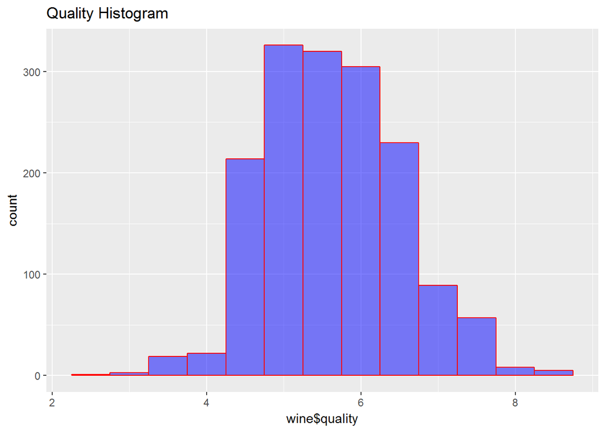

```r
wine <- fread("C:/Users/Arsovska/Desktop/winequality-csv.csv")

# Plot the histogram
qplot(wine$quality, geom = "histogram", binwidth = 0.5, main = "Quality Histogram",
    fill = I("blue"), col = I("red"), alpha = I(0.5))
```

```r
# Check the number of unique values
apply(wine, 2, function(x) length(unique(x)))
```

```
##        fixed.acidity     volatile.acidity          citric.acid
##                   96                  143                   80
##       residual.sugar            chlorides  free.sulfur.dioxide
##                   91                  153                   60
## total.sulfur.dioxide              density                   pH
##                  144                  436                   89
##            sulphates              alcohol              quality
##                   96                   65                  355
```

We can check the correlation between the features using the cor function. We also need to use the pair function for displaying the pairwise relations between variables in the data set. We need to analyse both the matrix and the diagram because a high correlation value in the matrix doesn’t imply two variables have a linear relationship.

```r
# Find the correlation between the features
round(cor(wine), 3)
```

```
##                      fixed.acidity volatile.acidity citric.acid
## fixed.acidity                1.000           -0.256       0.672
## volatile.acidity            -0.256            1.000      -0.552
## citric.acid                  0.672           -0.552       1.000
## residual.sugar               0.115            0.002       0.144
## chlorides                    0.094            0.061       0.204
## free.sulfur.dioxide         -0.154           -0.011      -0.061
## total.sulfur.dioxide        -0.113            0.076       0.036
## density                      0.668            0.022       0.365
## pH                          -0.683            0.235      -0.542
## sulphates                    0.183           -0.261       0.313
## alcohol                     -0.062           -0.202       0.110
## quality                      0.127           -0.377       0.220
##                      residual.sugar chlorides free.sulfur.dioxide
## fixed.acidity                 0.115     0.094              -0.154
## volatile.acidity              0.002     0.061              -0.011
## citric.acid                   0.144     0.204              -0.061
## residual.sugar                1.000     0.056               0.187
## chlorides                     0.056     1.000               0.006
## free.sulfur.dioxide           0.187     0.006               1.000
## total.sulfur.dioxide          0.203     0.047               0.668
## density                       0.355     0.201              -0.022
## pH                           -0.086    -0.265               0.070
## sulphates                     0.006     0.371               0.052
## alcohol                       0.042    -0.221              -0.069
## quality                       0.021    -0.121              -0.049
##                      total.sulfur.dioxide density     pH sulphates alcohol
## fixed.acidity                      -0.113   0.668 -0.683     0.183  -0.062
## volatile.acidity                    0.076   0.022  0.235    -0.261  -0.202
## citric.acid                         0.036   0.365 -0.542     0.313   0.110
## residual.sugar                      0.203   0.355 -0.086     0.006   0.042
## chlorides                           0.047   0.201 -0.265     0.371  -0.221
## free.sulfur.dioxide                 0.668  -0.022  0.070     0.052  -0.069
## total.sulfur.dioxide                1.000   0.071 -0.066     0.043  -0.206
## density                             0.071   1.000 -0.342     0.149  -0.496
## pH                                 -0.066  -0.342  1.000    -0.197   0.206
## sulphates                           0.043   0.149 -0.197     1.000   0.094
## alcohol                            -0.206  -0.496  0.206     0.094   1.000
## quality                            -0.177  -0.165 -0.062     0.230   0.450
##                      quality
## fixed.acidity          0.127
## volatile.acidity      -0.377
## citric.acid            0.220
## residual.sugar         0.021
## chlorides             -0.121
## free.sulfur.dioxide   -0.049
## total.sulfur.dioxide  -0.177
## density               -0.165
## pH                    -0.062
## sulphates              0.230
## alcohol                0.450
## quality                1.000
```

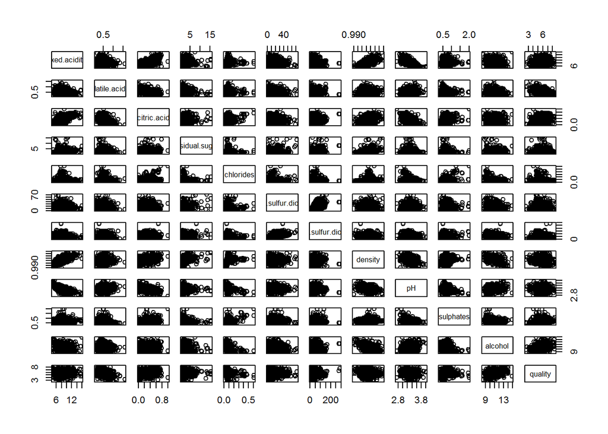

```r
pairs(wine)
```

From the correlation matrix we can notice that quality has high correlation with alcohol. Many of the features have high correlation (for example the value of the correlation between density and fixed.acidity is 0.668) which can be a problem if we include them in the model because R will not be able to make a difference about the feature’s contribution.

Because quality has highest correlation with alcohol we can create the model first with this feature.

```r
model1 <- lm(quality ~ alcohol, data = wine)
summary(model1)
```

```
##
## Call:
## lm(formula = quality ~ alcohol, data = wine)
##
## Residuals:
##      Min       1Q   Median       3Q      Max
## -3.06114 -0.51660 -0.02887  0.50220  2.94153
##
## Coefficients:
##             Estimate Std. Error t value Pr(>|t|)
## (Intercept)  1.85178    0.18874   9.811   <2e-16 ***
## alcohol      0.36267    0.01801  20.132   <2e-16 ***
## ---
## Signif. codes:  0 '***' 0.001 '**' 0.01 '*' 0.05 '.' 0.1 ' ' 1
##
## Residual standard error: 0.7674 on 1597 degrees of freedom
## Multiple R-squared:  0.2024, Adjusted R-squared:  0.2019
## F-statistic: 405.3 on 1 and 1597 DF,  p-value: < 2.2e-16
```

The value of R-squared is low and we can try to improve it by adding more features. Next we can add volatile.acidity and continue adding features one by one based on their correlation with the quality. Features with small significance codes which do not improve the model will be removed.

```r
model2 <- lm(quality ~ alcohol + volatile.acidity, data = wine)
summary(model2)
```

```
##
## Call:
## lm(formula = quality ~ alcohol + volatile.acidity, data = wine)
##
## Residuals:
##      Min       1Q   Median       3Q      Max
## -2.64793 -0.48784 -0.03594  0.47353  2.63799
##
## Coefficients:
##                  Estimate Std. Error t value Pr(>|t|)
## (Intercept)       3.11357    0.20042   15.54   <2e-16 ***
## alcohol           0.31405    0.01739   18.06   <2e-16 ***
## volatile.acidity -1.43045    0.10349  -13.82   <2e-16 ***
## ---
## Signif. codes:  0 '***' 0.001 '**' 0.01 '*' 0.05 '.' 0.1 ' ' 1
##
## Residual standard error: 0.7255 on 1596 degrees of freedom
## Multiple R-squared:  0.2877, Adjusted R-squared:  0.2868
## F-statistic: 322.3 on 2 and 1596 DF,  p-value: < 2.2e-16
```

```r
model3 <- lm(quality ~ alcohol + volatile.acidity + sulphates, data = wine)
summary(model3)
```

```
##
## Call:
## lm(formula = quality ~ alcohol + volatile.acidity + sulphates,
##     data = wine)
##
## Residuals:
##      Min       1Q   Median       3Q      Max
## -2.71811 -0.48270 -0.01813  0.47834  2.38775
##
## Coefficients:
##                  Estimate Std. Error t value Pr(>|t|)
## (Intercept)       2.66419    0.21340  12.485  < 2e-16 ***
## alcohol           0.30979    0.01723  17.975  < 2e-16 ***
## volatile.acidity -1.28002    0.10579 -12.100  < 2e-16 ***
## sulphates         0.62963    0.10992   5.728 1.21e-08 ***
## ---
## Signif. codes:  0 '***' 0.001 '**' 0.01 '*' 0.05 '.' 0.1 ' ' 1
##
## Residual standard error: 0.7183 on 1595 degrees of freedom
## Multiple R-squared:  0.302,  Adjusted R-squared:  0.3007
## F-statistic: 230.1 on 3 and 1595 DF,  p-value: < 2.2e-16
```

```r
model4 <- lm(quality ~ alcohol + volatile.acidity + sulphates + citric.acid,
    data = wine)
summary(model4)
```

```
##
## Call:
## lm(formula = quality ~ alcohol + volatile.acidity + sulphates +
##     citric.acid, data = wine)
##
## Residuals:
##      Min       1Q   Median       3Q      Max
## -2.70372 -0.48938 -0.01983  0.47659  2.37973
##
## Coefficients:
##                  Estimate Std. Error t value Pr(>|t|)
## (Intercept)       2.68906    0.21927  12.264  < 2e-16 ***
## alcohol           0.30969    0.01724  17.964  < 2e-16 ***
## volatile.acidity -1.31097    0.12287 -10.669  < 2e-16 ***
## sulphates         0.64131    0.11245   5.703  1.4e-08 ***
## citric.acid      -0.05608    0.11322  -0.495     0.62
## ---
## Signif. codes:  0 '***' 0.001 '**' 0.01 '*' 0.05 '.' 0.1 ' ' 1
##
## Residual standard error: 0.7185 on 1594 degrees of freedom
## Multiple R-squared:  0.3022, Adjusted R-squared:  0.3004
## F-statistic: 172.5 on 4 and 1594 DF,  p-value: < 2.2e-16
```

```r
# Remove citric.acid
model5 <- lm(quality ~ alcohol + volatile.acidity + sulphates + total.sulfur.dioxide,
    data = wine)
summary(model5)
```

```
##
## Call:
## lm(formula = quality ~ alcohol + volatile.acidity + sulphates +
##     total.sulfur.dioxide, data = wine)
##
## Residuals:
##      Min       1Q   Median       3Q      Max
## -2.60144 -0.47568 -0.01667  0.47498  2.31584
##
## Coefficients:
##                        Estimate Std. Error t value Pr(>|t|)
## (Intercept)           2.8824437  0.2190238  13.160  < 2e-16 ***
## alcohol               0.2956687  0.0174979  16.897  < 2e-16 ***
## volatile.acidity     -1.2568344  0.1054264 -11.921  < 2e-16 ***
## sulphates             0.6632427  0.1096975   6.046 1.84e-09 ***
## total.sulfur.dioxide -0.0022694  0.0005574  -4.071 4.91e-05 ***
## ---
## Signif. codes:  0 '***' 0.001 '**' 0.01 '*' 0.05 '.' 0.1 ' ' 1
##
## Residual standard error: 0.7149 on 1594 degrees of freedom
## Multiple R-squared:  0.3092, Adjusted R-squared:  0.3075
## F-statistic: 178.4 on 4 and 1594 DF,  p-value: < 2.2e-16
```

```r
model6 <- lm(quality ~ alcohol + volatile.acidity + sulphates + total.sulfur.dioxide +
    density, data = wine)
summary(model6)
```

```
##
## Call:
## lm(formula = quality ~ alcohol + volatile.acidity + sulphates +
##     total.sulfur.dioxide + density, data = wine)
##
## Residuals:
##      Min       1Q   Median       3Q      Max
## -2.62910 -0.47309 -0.01786  0.47380  2.32482
##
## Coefficients:
##                        Estimate Std. Error t value Pr(>|t|)
## (Intercept)          -3.0735501 11.2894050  -0.272    0.785
## alcohol               0.3012237  0.0204239  14.749  < 2e-16 ***
## volatile.acidity     -1.2548524  0.1055172 -11.892  < 2e-16 ***
## sulphates             0.6506023  0.1123069   5.793 8.31e-09 ***
## total.sulfur.dioxide -0.0022546  0.0005583  -4.039 5.63e-05 ***
## density               5.9239549 11.2265620   0.528    0.598
## ---
## Signif. codes:  0 '***' 0.001 '**' 0.01 '*' 0.05 '.' 0.1 ' ' 1
##
## Residual standard error: 0.715 on 1593 degrees of freedom
## Multiple R-squared:  0.3093, Adjusted R-squared:  0.3072
## F-statistic: 142.7 on 5 and 1593 DF,  p-value: < 2.2e-16
```

```r
# remove density
model7 <- lm(quality ~ alcohol + volatile.acidity + sulphates + total.sulfur.dioxide +
    fixed.acidity, data = wine)
summary(model7)
```

```
##
## Call:
## lm(formula = quality ~ alcohol + volatile.acidity + sulphates +
##     total.sulfur.dioxide + fixed.acidity, data = wine)
##
## Residuals:
##      Min       1Q   Median       3Q      Max
## -2.82414 -0.45902 -0.01679  0.46480  2.36495
##
## Coefficients:
##                        Estimate Std. Error t value Pr(>|t|)
## (Intercept)           2.5703671  0.2518561  10.206  < 2e-16 ***
## alcohol               0.3023440  0.0176725  17.108  < 2e-16 ***
## volatile.acidity     -1.1934705  0.1082689 -11.023  < 2e-16 ***
## sulphates             0.6241460  0.1106311   5.642 1.99e-08 ***
## total.sulfur.dioxide -0.0020799  0.0005617  -3.703  0.00022 ***
## fixed.acidity         0.0271626  0.0108770   2.497  0.01262 *
## ---
## Signif. codes:  0 '***' 0.001 '**' 0.01 '*' 0.05 '.' 0.1 ' ' 1
##
## Residual standard error: 0.7137 on 1593 degrees of freedom
## Multiple R-squared:  0.3119, Adjusted R-squared:  0.3098
## F-statistic: 144.4 on 5 and 1593 DF,  p-value: < 2.2e-16
```

```r
model8 <- lm(quality ~ alcohol + volatile.acidity + sulphates + total.sulfur.dioxide +
    fixed.acidity + chlorides, data = wine)
summary(model8)
```

```
##
## Call:
## lm(formula = quality ~ alcohol + volatile.acidity + sulphates +
##     total.sulfur.dioxide + fixed.acidity + chlorides, data = wine)
##
## Residuals:
##      Min       1Q   Median       3Q      Max
## -2.76867 -0.46662 -0.01522  0.46267  2.31033
##
## Coefficients:
##                        Estimate Std. Error t value Pr(>|t|)
## (Intercept)           2.7247009  0.2540497  10.725  < 2e-16 ***
## alcohol               0.2853059  0.0181581  15.712  < 2e-16 ***
## volatile.acidity     -1.1359581  0.1088659 -10.434  < 2e-16 ***
## sulphates             0.8156525  0.1211025   6.735 2.28e-11 ***
## total.sulfur.dioxide -0.0021406  0.0005595  -3.826 0.000135 ***
## fixed.acidity         0.0286172  0.0108380   2.640 0.008360 **
## chlorides            -1.6283155  0.4276264  -3.808 0.000146 ***
## ---
## Signif. codes:  0 '***' 0.001 '**' 0.01 '*' 0.05 '.' 0.1 ' ' 1
##
## Residual standard error: 0.7107 on 1592 degrees of freedom
## Multiple R-squared:  0.3181, Adjusted R-squared:  0.3156
## F-statistic: 123.8 on 6 and 1592 DF,  p-value: < 2.2e-16
```

```r
model9 <- lm(quality ~ alcohol + volatile.acidity + sulphates + total.sulfur.dioxide +
    fixed.acidity + chlorides + pH, data = wine)
summary(model9)
```

```
##
## Call:
## lm(formula = quality ~ alcohol + volatile.acidity + sulphates +
##     total.sulfur.dioxide + fixed.acidity + chlorides + pH, data = wine)
##
## Residuals:
##      Min       1Q   Median       3Q      Max
## -2.74435 -0.45945 -0.01502  0.45755  2.23093
##
## Coefficients:
##                       Estimate Std. Error t value Pr(>|t|)
## (Intercept)           4.361393   0.666726   6.542 8.19e-11 ***
## alcohol               0.293474   0.018383  15.964  < 2e-16 ***
## volatile.acidity     -1.089453   0.110063  -9.898  < 2e-16 ***
## sulphates             0.821338   0.120892   6.794 1.54e-11 ***
## total.sulfur.dioxide -0.002384   0.000566  -4.213 2.66e-05 ***
## fixed.acidity         0.002787   0.014551   0.192  0.84812
## chlorides            -1.902072   0.439101  -4.332 1.57e-05 ***
## pH                   -0.453003   0.170669  -2.654  0.00803 **
## ---
## Signif. codes:  0 '***' 0.001 '**' 0.01 '*' 0.05 '.' 0.1 ' ' 1
##
## Residual standard error: 0.7093 on 1591 degrees of freedom
## Multiple R-squared:  0.3211, Adjusted R-squared:  0.3182
## F-statistic: 107.5 on 7 and 1591 DF,  p-value: < 2.2e-16
```

```r
# remove fixed.acidity
model10 <- lm(quality ~ alcohol + volatile.acidity + sulphates + total.sulfur.dioxide +
    chlorides + pH + free.sulfur.dioxide, data = wine)
summary(model10)
```

```
##
## Call:
## lm(formula = quality ~ alcohol + volatile.acidity + sulphates +
##     total.sulfur.dioxide + chlorides + pH + free.sulfur.dioxide,
##     data = wine)
##
## Residuals:
##      Min       1Q   Median       3Q      Max
## -2.73883 -0.44966 -0.00937  0.45232  2.21068
##
## Coefficients:
##                        Estimate Std. Error t value Pr(>|t|)
## (Intercept)           4.5964263  0.4405284  10.434  < 2e-16 ***
## alcohol               0.2920983  0.0183636  15.906  < 2e-16 ***
## volatile.acidity     -1.0646361  0.1102565  -9.656  < 2e-16 ***
## sulphates             0.8173714  0.1201682   6.802 1.46e-11 ***
## total.sulfur.dioxide -0.0035516  0.0007509  -4.730 2.45e-06 ***
## chlorides            -1.9291573  0.4346516  -4.438 9.69e-06 ***
## pH                   -0.5238294  0.1285319  -4.075 4.82e-05 ***
## free.sulfur.dioxide   0.0052361  0.0023239   2.253   0.0244 *
## ---
## Signif. codes:  0 '***' 0.001 '**' 0.01 '*' 0.05 '.' 0.1 ' ' 1
##
## Residual standard error: 0.7082 on 1591 degrees of freedom
## Multiple R-squared:  0.3233, Adjusted R-squared:  0.3203
## F-statistic: 108.6 on 7 and 1591 DF,  p-value: < 2.2e-16
```

```r
model11 <- lm(quality ~ alcohol + volatile.acidity + sulphates + total.sulfur.dioxide +
    chlorides + pH + free.sulfur.dioxide + residual.sugar, data = wine)
summary(model11)
```

```
##
## Call:
## lm(formula = quality ~ alcohol + volatile.acidity + sulphates +
##     total.sulfur.dioxide + chlorides + pH + free.sulfur.dioxide +
##     residual.sugar, data = wine)
##
## Residuals:
##     Min      1Q  Median      3Q     Max
## -2.7840 -0.4496 -0.0102  0.4567  2.2168
##
## Coefficients:
##                        Estimate Std. Error t value Pr(>|t|)
## (Intercept)           4.5530042  0.4430226  10.277  < 2e-16 ***
## alcohol               0.2900589  0.0184953  15.683  < 2e-16 ***
## volatile.acidity     -1.0668906  0.1102880  -9.674  < 2e-16 ***
## sulphates             0.8232715  0.1203413   6.841 1.12e-11 ***
## total.sulfur.dioxide -0.0036279  0.0007554  -4.803 1.71e-06 ***
## chlorides            -1.9536769  0.4354718  -4.486 7.77e-06 ***
## pH                   -0.5118139  0.1291872  -3.962 7.77e-05 ***
## free.sulfur.dioxide   0.0050600  0.0023318   2.170   0.0302 *
## residual.sugar        0.0120881  0.0130184   0.929   0.3533
## ---
## Signif. codes:  0 '***' 0.001 '**' 0.01 '*' 0.05 '.' 0.1 ' ' 1
##
## Residual standard error: 0.7082 on 1590 degrees of freedom
## Multiple R-squared:  0.3236, Adjusted R-squared:  0.3202
## F-statistic: 95.11 on 8 and 1590 DF,  p-value: < 2.2e-16
```

```r
# remove residual sugar
final <- lm(quality ~ alcohol + volatile.acidity + sulphates + total.sulfur.dioxide +
    chlorides + pH, data = wine)
summary(final)
```

```
##
## Call:
## lm(formula = quality ~ alcohol + volatile.acidity + sulphates +
##     total.sulfur.dioxide + chlorides + pH, data = wine)
##
## Residuals:
##      Min       1Q   Median       3Q      Max
## -2.73063 -0.46011 -0.01463  0.45729  2.22482
##
## Coefficients:
##                        Estimate Std. Error t value Pr(>|t|)
## (Intercept)           4.4578598  0.4367725  10.206  < 2e-16 ***
## alcohol               0.2935122  0.0183764  15.972  < 2e-16 ***
## volatile.acidity     -1.0908730  0.1097801  -9.937  < 2e-16 ***
## sulphates             0.8235744  0.1202904   6.847 1.08e-11 ***
## total.sulfur.dioxide -0.0024068  0.0005536  -4.348 1.46e-05 ***
## chlorides            -1.9131420  0.4351495  -4.397 1.17e-05 ***
## pH                   -0.4748671  0.1268436  -3.744 0.000188 ***
## ---
## Signif. codes:  0 '***' 0.001 '**' 0.01 '*' 0.05 '.' 0.1 ' ' 1
##
## Residual standard error: 0.7091 on 1592 degrees of freedom
## Multiple R-squared:  0.3211, Adjusted R-squared:  0.3186
## F-statistic: 125.5 on 6 and 1592 DF,  p-value: < 2.2e-16
```

The final model is: $quality = 4.457 + 0.293(alcohol) - 1.09(volatile.acidity) + 0.823(sulphates) - 0.0024(total.sulfur.dioxide) - 1.913(chlorides) - 0.474(pH)$

Although all features are significant the adjusted R value is still small and we only manage to describe around 31% of the variance.

We can get the same results if we start with all features and removed them one by one.

```r
linearModelAllVar = lm(quality ~ ., data = wine)
summary(linearModelAllVar)
```

```
##
## Call:
## lm(formula = quality ~ ., data = wine)
##
## Residuals:
##      Min       1Q   Median       3Q      Max
## -2.96364 -0.45791 -0.01146  0.45230  2.25323
##
## Coefficients:
##                        Estimate Std. Error t value Pr(>|t|)
## (Intercept)           4.061e+01  2.315e+01   1.754  0.07965 .
## fixed.acidity         4.950e-02  2.835e-02   1.746  0.08096 .
## volatile.acidity     -1.137e+00  1.323e-01  -8.595  < 2e-16 ***
## citric.acid          -2.197e-01  1.608e-01  -1.366  0.17199
## residual.sugar        2.848e-02  1.639e-02   1.738  0.08245 .
## chlorides            -1.713e+00  4.581e-01  -3.741  0.00019 ***
## free.sulfur.dioxide   4.215e-03  2.372e-03   1.777  0.07581 .
## total.sulfur.dioxide -3.226e-03  7.961e-04  -4.053 5.31e-05 ***
## density              -3.693e+01  2.363e+01  -1.562  0.11839
## pH                   -3.223e-01  2.093e-01  -1.540  0.12385
## sulphates             8.754e-01  1.249e-01   7.008 3.56e-12 ***
## alcohol               2.616e-01  2.893e-02   9.042  < 2e-16 ***
## ---
## Signif. codes:  0 '***' 0.001 '**' 0.01 '*' 0.05 '.' 0.1 ' ' 1
##
## Residual standard error: 0.7079 on 1587 degrees of freedom
## Multiple R-squared:  0.3255, Adjusted R-squared:  0.3208
## F-statistic: 69.62 on 11 and 1587 DF,  p-value: < 2.2e-16
```

If we remove the features based on the significance codes in the end the features that will remain are: alcohol, volatile.acidity, sulphates, total.sulfur.dioxide, chlorides and pH.

## Exercise 3

Use the iris data set for testing differences of means with a t-test. First present your hypothesis (what are you going to check with the t-test). For formulating the hypothesis you need to choose a feature and two different flower types (ie Virginica, Setosa - you can choose the pair yourself). Then you can check whether the feature means of 2 different Iris flowers differ from each other with a pre-implemented t-test method.

Next, recreate this calculation by implementing two-sample t-test yourself. To do that, first calculate the t-statistic (you can find the formula online or from the lecture slides). Then use the distribution function of t-distribution to convert the t-statistic to p-value. Are the two classes means different (p-value)? Interpret and explain all steps and answers.

Present a visual illustration that would support your conclusion (plot the distributions for example).

**Solution:**

The T test is a parametric method which is appropriate for examining the difference between the means of 2 features.

This test asks whether a difference between two groups’ averages is unlikely to have occurred because of random chance in sample selection. A difference is more likely to be meaningful and “real” if:

- the difference between the averages is large,
- the sample size is large, and
- responses are consistently close to the average values and not widely spread out (the standard deviation is low).

The t-test’s statistical significance and the t-test’s effect size are the two primary outputs of the t-test. Statistical significance indicates whether the difference between sample averages is likely to represent an actual difference between populations, and the effect size indicates whether that difference is large enough to be practically meaningful.

The iris data set contains 3 classes of 50 instances each, where each class refers to a type of iris plant. The attributes in this data set are the sepal length (cm), the sepal width (cm), the petal length (cm), the petal width (cm) and the species of the flower (Setosa, Versicolour and Virginica).

First we can create a box plot which will compare the sepal length and the distributions. Checking the form of the distribution is also important because the test assumes that the sampling distribution is approximately normal.

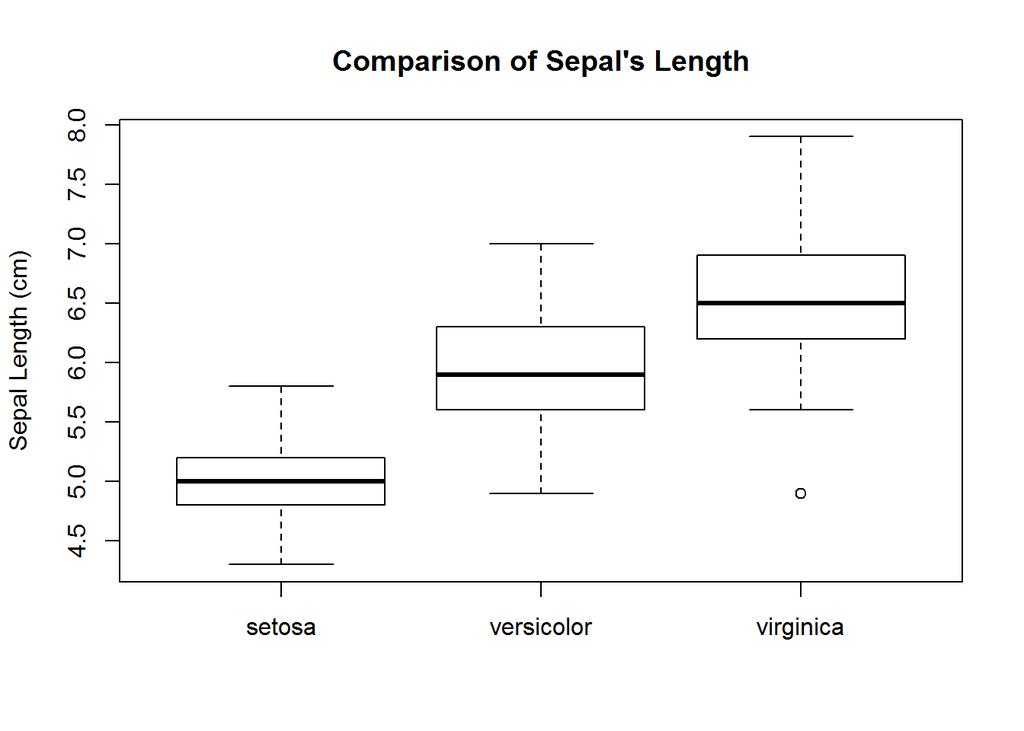

```r
library(ggplot2)
attach(iris)
boxplot(iris$Sepal.Length ~ iris$Species, ylab = "Sepal Length (cm)", main = "Comparison of Sepal's Length")
```

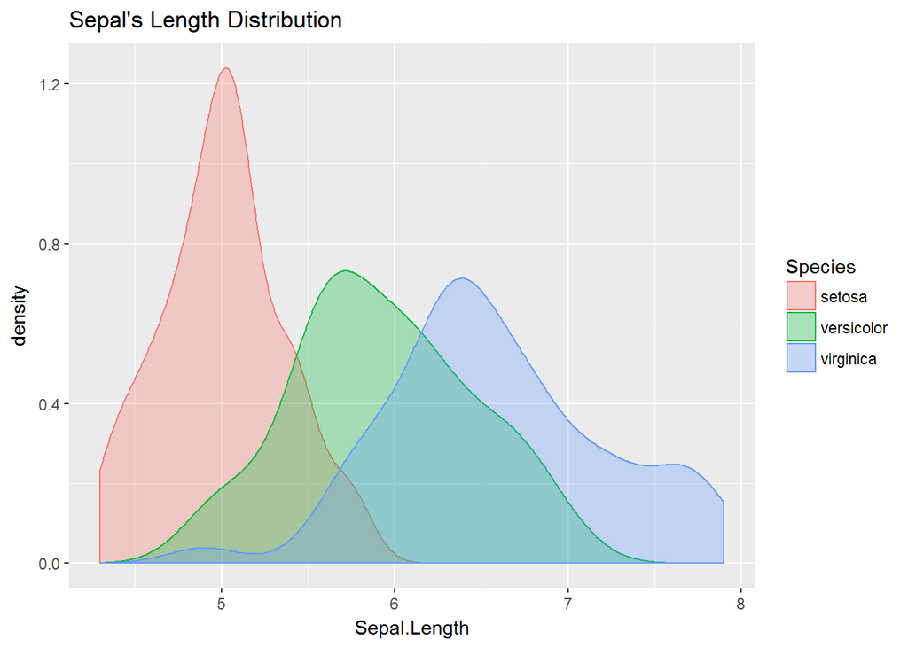

```r
ggplot(iris, aes(x = Sepal.Length)) + geom_density(aes(group = Species, colour = Species,
    fill = Species), alpha = 0.3) + ggtitle("Sepal's Length Distribution")
```

From the box plot we can notice that the sepal length seems to increase from setosa to versicolor to virginica. To comfirm this we can calculate the mean sepal length for each species.

```r
tapply(iris$Sepal.Length, iris$Species, mean)
```

```
##     setosa versicolor  virginica
##      5.006      5.936      6.588
```

Then we state the null and the hypothesis. The null hypothesis states that the mean of the Setosa’s sepal length is same as the Virginica sepal’s length. The alternative hypothesis is that they are different.

We can choose the significance level to be 0.05. For computing the two-sided T test we can use the command t.test in R.

```r
t.test(iris$Sepal.Length[iris$Species == "setosa"], iris$Sepal.Length[iris$Species ==
    "virginica"])
```

```
##
##  Welch Two Sample t-test
##
## data:  iris$Sepal.Length[iris$Species == "setosa"] and iris$Sepal.Length[iris$Species == "virginica"]
## t = -15.386, df = 76.516, p-value < 2.2e-16
## alternative hypothesis: true difference in means is not equal to 0
## 95 percent confidence interval:
##  -1.78676 -1.37724
## sample estimates:
## mean of x mean of y
##     5.006     6.588
```

If we analyze the results from this test we can notice that the t value is different from 0 and the p value is smaller then 0.05 we can reject the null hypothesis and we can conclude that the there is a significant difference in sepal length. Sepals of species Virginica are on average 1.6 cm longer than sepals of species Setosa.

Similarly we can choose the feature Sepal width and plot the box plot and the distribution.

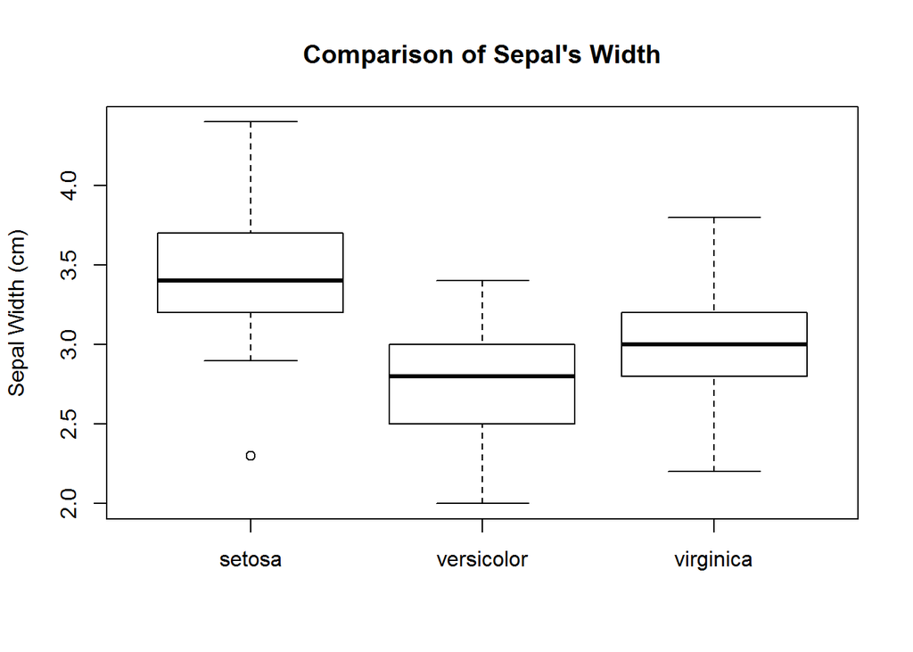

```r
boxplot(iris$Sepal.Width ~ iris$Species, ylab = "Sepal Width (cm)", main = "Comparison of Sepal's Width")
```

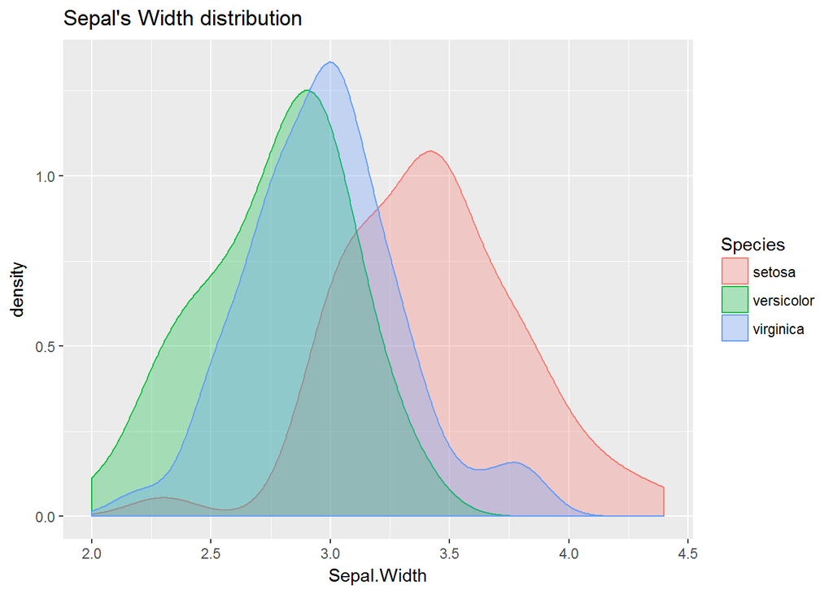

```r
ggplot(iris, aes(x = Sepal.Width)) + geom_density(aes(group = Species, colour = Species,
    fill = Species), alpha = 0.3) + ggtitle("Sepal's Width distribution")
```

We can state the null hypothesis that the means of the sepal’s width are same and the alternative hypothesis that they are the same. We can calculate the pairwise T test which will compare the width of the sepals for all species.

```r
pairwise.t.test(iris$Sepal.Width, iris$Species)
```

```
##
##  Pairwise comparisons using t tests with pooled SD
##
## data:  iris$Sepal.Width and iris$Species
##
##            setosa  versicolor
## versicolor < 2e-16 -
## virginica  9.1e-10 0.0031
##
## P value adjustment method: holm
```

Using the formula for the t value, the p value and the degrees of freedom we can recreate the 2 sample T test that compares the length of the sepals for the species setosa and virginica.

```r
# Average values
tapply(iris$Sepal.Length, iris$Species, mean)
```

```
##     setosa versicolor  virginica
##      5.006      5.936      6.588
```

```r
t.test2 <- function(m1, m2, s1, s2, n1, n2, m0 = 0, equal.variance = FALSE) {
    if (equal.variance == FALSE) {
        se <- sqrt((s1^2/n1) + (s2^2/n2))
        # welch-satterthwaite df
        df <- ((s1^2/n1 + s2^2/n2)^2)/((s1^2/n1)^2/(n1 - 1) + (s2^2/n2)^2/(n2 -
            1))
    }
    t <- (m1 - m2 - m0)/se
    dat <- c(df, m1 - m2, se, t, 2 * pt(-abs(t), df))
    names(dat) <- c("Degrees of freedom", "Difference of means", "Std Error",
        "t", "p-value")
    return(dat)
}
```

```r
a <- subset(iris, iris$Species == "setosa")
b <- subset(iris, iris$Species == "virginica")
t.test2(mean(a$Sepal.Length), mean(b$Sepal.Length), sd(a$Sepal.Length), sd(b$Sepal.Length),
    50, 50)
```

```
##  Degrees of freedom Difference of means           Std Error
##        7.651587e+01       -1.582000e+00        1.028194e-01
##                   t             p-value
##       -1.538620e+01        3.966867e-25
```

The returned values are:

- degrees of freedom: $76.51$
- t value: $- 15.386$
- p value: $3.966867e-25$

We can compare the values with the ones obtained previously using the built in function and conclude that they are the same.

```r
a <- t.test(iris$Sepal.Length[iris$Species == "setosa"], iris$Sepal.Length[iris$Species ==
    "virginica"])
a[1]
```

```
## $statistic
##        t
## -15.3862
```

```r
a[2]
```

```
## $parameter
##       df
## 76.51587
```

```r
a[3]
```

```
## $p.value
## [1] 3.966867e-25
```

## Exercise 4

In this task we are using diamonds data from the package ggplot2 (data(diamonds)). Build regression models predicting price from the rest of the features, where

1. model 1 has all the features
2. model 2 has all the features + ‘carat’ and ‘depth’ of degree 2
3. model 3 has all the features + 3rd degree polynomials of ‘carat’ and ‘depth’ (i.e. carat^3, carat^2, carat, depth^3,…)
4. model 4 has all the features + 3rd degree polynomials of ‘carat’ and ‘depth’ + ‘x’,‘y’,‘z’ of degree 2 In R you can use poly(x,d) to evaluate a polynomial of degree d, e.g. lm(price ~ poly(x,3) + …, data=diamonds).

Use the regular 80% train / 20% test split. Measure the RMSE for all the models on the train and test set and plot a graph, where on x-axis models are sorted according to the complexity of the model (A, B, C, D) and on y-axis RMSE for train and test split (one line for train, other for test RMSE’s). What do you observe? Can we diagnose under- or overfitting problems?

**Solution:**

```r
Diamonds <- fread("C:/Users/Arsovska/Desktop/diamonds-csv.csv")
```

The Diamonds data set consists of 10 columns:

- carat
- cut
- color
- clarity
- depth
- table
- price
- x
- y
- z

First we can examine the data and see the type of the features that will be used for prediction.

```r
apply(Diamonds, 2, function(x) length(unique(x)))
```

```
##  Column   carat     cut   color clarity   depth   table   price       x
##   53940     273       5       7       8     184     127   11602     554
##       y       z
##     552     375
```

Next we can define the training and the test data.

```r
set.seed(2)

bound <- floor((nrow(Diamonds)/4) * 3.2)  #define 80%
df <- Diamonds[sample(nrow(Diamonds)), ]  #sample rows
df.train <- Diamonds[1:bound, ]  #get training set (80%)
df.test <- Diamonds[(bound + 1):nrow(Diamonds), ]  #get test set (20%)
```

```r
carat <- df.test$carat
cut <- df.test$cut
color <- df.test$color
clarity <- df.test$clarity
depth <- df.test$depth
table <- df.test$table
x <- df.test$x
y <- df.test$y
z <- df.test$z
```

After the training and the test data is defined we can build the models. Model A has all the features.

```r
# Model A
modelA <- lm(price ~ carat + cut + color + clarity + depth + table + x + y +
    z, data = df.train)
summary(modelA)
```

```
##
## Call:
## lm(formula = price ~ carat + cut + color + clarity + depth +
##     table + x + y + z, data = df.train)
##
## Residuals:
##      Min       1Q   Median       3Q      Max
## -20093.8   -665.8   -186.3    438.4  10422.4
##
## Coefficients:
##               Estimate Std. Error t value Pr(>|t|)
## (Intercept)    886.262    535.334   1.656   0.0978 .
## carat        10921.535     56.135 194.558   <2e-16 ***
## cutGood        696.324     40.879  17.034   <2e-16 ***
## cutIdeal       988.505     40.631  24.329   <2e-16 ***
## cutPremium     883.006     39.262  22.490   <2e-16 ***
## cutVery Good   870.053     39.288  22.146   <2e-16 ***
## colorE        -228.216     21.800 -10.469   <2e-16 ***
## colorF        -286.293     21.948 -13.044   <2e-16 ***
## colorG        -523.208     21.428 -24.417   <2e-16 ***
## colorH       -1094.363     22.533 -48.566   <2e-16 ***
## colorI       -1613.798     25.373 -63.603   <2e-16 ***
## colorJ       -2640.467     31.001 -85.173   <2e-16 ***
## clarityIF     5877.416     60.853  96.584   <2e-16 ***
## claritySI1    4077.068     52.534  77.608   <2e-16 ***
## claritySI2    3017.607     52.638  57.327   <2e-16 ***
## clarityVS1    5100.062     53.640  95.080   <2e-16 ***
## clarityVS2    4784.996     52.814  90.600   <2e-16 ***
## clarityVVS1   5522.517     56.593  97.583   <2e-16 ***
## clarityVVS2   5508.583     55.227  99.745   <2e-16 ***
## depth          -57.993      6.486  -8.941   <2e-16 ***
## table          -31.224      3.525  -8.858   <2e-16 ***
## x             -811.641     49.672 -16.340   <2e-16 ***
## y               28.896     23.687   1.220   0.2225
## z             -114.281     70.334  -1.625   0.1042
## ---
## Signif. codes:  0 '***' 0.001 '**' 0.01 '*' 0.05 '.' 0.1 ' ' 1
##
## Residual standard error: 1210 on 43128 degrees of freedom
## Multiple R-squared:  0.9209, Adjusted R-squared:  0.9209
## F-statistic: 2.184e+04 on 23 and 43128 DF,  p-value: < 2.2e-16
```

Model B has all the features + ‘carat’ and ‘depth’ of degree 2.

```r
# Model B
CaratSq <- df.train$carat^2  # add variablea to the dataset
DepthSq <- df.train$depth^2
df.trainB <- cbind(df.train, CaratSq, DepthSq)
modelB <- lm(price ~ carat + cut + color + clarity + depth + table + x + y +
    z + CaratSq + DepthSq, data = df.trainB)
summary(modelB)
```

```
##
## Call:
## lm(formula = price ~ carat + cut + color + clarity + depth +
##     table + x + y + z + CaratSq + DepthSq, data = df.trainB)
##
## Residuals:
##      Min       1Q   Median       3Q      Max
## -14104.0   -672.4   -190.3    451.2  10381.8
##
## Coefficients:
##                Estimate Std. Error t value Pr(>|t|)
## (Intercept)  -28990.252   5003.032  -5.795 6.90e-09 ***
## carat         15630.805    180.492  86.601  < 2e-16 ***
## cutGood         512.863     45.259  11.332  < 2e-16 ***
## cutIdeal        757.277     48.945  15.472  < 2e-16 ***
## cutPremium      673.564     47.140  14.288  < 2e-16 ***
## cutVery Good    636.736     46.539  13.682  < 2e-16 ***
## colorE         -228.689     21.601 -10.587  < 2e-16 ***
## colorF         -295.387     21.750 -13.581  < 2e-16 ***
## colorG         -536.651     21.238 -25.268  < 2e-16 ***
## colorH        -1108.021     22.334 -49.611  < 2e-16 ***
## colorI        -1612.547     25.142 -64.137  < 2e-16 ***
## colorJ        -2623.503     30.725 -85.387  < 2e-16 ***
## clarityIF      5713.345     60.663  94.181  < 2e-16 ***
## claritySI1     3920.396     52.430  74.774  < 2e-16 ***
## claritySI2     2868.601     52.506  54.634  < 2e-16 ***
## clarityVS1     4932.770     53.570  92.081  < 2e-16 ***
## clarityVS2     4615.466     52.753  87.493  < 2e-16 ***
## clarityVVS1    5356.929     56.476  94.854  < 2e-16 ***
## clarityVVS2    5337.111     55.148  96.779  < 2e-16 ***
## depth          1124.107    164.506   6.833 8.41e-12 ***
## table           -42.981      3.520 -12.212  < 2e-16 ***
## x             -1870.945     62.335 -30.015  < 2e-16 ***
## y                -8.365     23.511  -0.356  0.72201
## z              -206.797     69.930  -2.957  0.00311 **
## CaratSq        -955.667     34.875 -27.403  < 2e-16 ***
## DepthSq         -10.065      1.346  -7.477 7.77e-14 ***
## ---
## Signif. codes:  0 '***' 0.001 '**' 0.01 '*' 0.05 '.' 0.1 ' ' 1
##
## Residual standard error: 1199 on 43126 degrees of freedom
## Multiple R-squared:  0.9224, Adjusted R-squared:  0.9223
## F-statistic: 2.05e+04 on 25 and 43126 DF,  p-value: < 2.2e-16
```

Model C has all the features + 3rd degree polynomials of ‘carat’ and ‘depth’.

```r
# Model C
Caratcub <- df.train$carat^3
Depthcub <- df.train$depth^3
df.trainC <- cbind(df.trainB, Caratcub, Depthcub)
modelC <- lm(price ~ carat + cut + color + clarity + depth + table + x + y +
    z + CaratSq + DepthSq + Caratcub + Depthcub, data = df.trainC)
summary(modelC)
```

```
##
## Call:
## lm(formula = price ~ carat + cut + color + clarity + depth +
##     table + x + y + z + CaratSq + DepthSq + Caratcub + Depthcub,
##     data = df.trainC)
##
## Residuals:
##      Min       1Q   Median       3Q      Max
## -11191.3   -638.6   -171.2    431.1  21828.1
##
## Coefficients:
##                Estimate Std. Error t value Pr(>|t|)
## (Intercept)  -1.464e+04  2.280e+04  -0.642    0.521
## carat         5.329e+03  2.583e+02  20.635  < 2e-16 ***
## cutGood       4.877e+02  4.448e+01  10.964  < 2e-16 ***
## cutIdeal      7.063e+02  4.807e+01  14.694  < 2e-16 ***
## cutPremium    5.927e+02  4.632e+01  12.795  < 2e-16 ***
## cutVery Good  6.155e+02  4.575e+01  13.453  < 2e-16 ***
## colorE       -2.366e+02  2.090e+01 -11.318  < 2e-16 ***
## colorF       -2.924e+02  2.105e+01 -13.895  < 2e-16 ***
## colorG       -5.425e+02  2.055e+01 -26.399  < 2e-16 ***
## colorH       -1.132e+03  2.161e+01 -52.391  < 2e-16 ***
## colorI       -1.671e+03  2.435e+01 -68.604  < 2e-16 ***
## colorJ       -2.672e+03  2.975e+01 -89.843  < 2e-16 ***
## clarityIF     5.481e+03  5.897e+01  92.947  < 2e-16 ***
## claritySI1    3.726e+03  5.103e+01  73.012  < 2e-16 ***
## claritySI2    2.665e+03  5.110e+01  52.147  < 2e-16 ***
## clarityVS1    4.731e+03  5.212e+01  90.777  < 2e-16 ***
## clarityVS2    4.413e+03  5.135e+01  85.937  < 2e-16 ***
## clarityVVS1   5.130e+03  5.495e+01  93.372  < 2e-16 ***
## clarityVVS2   5.122e+03  5.365e+01  95.468  < 2e-16 ***
## depth         5.768e+01  1.127e+03   0.051    0.959
## table        -2.828e+01  3.423e+00  -8.261  < 2e-16 ***
## x            -4.118e+02  6.627e+01  -6.215 5.18e-10 ***
## y             2.984e+01  2.277e+01   1.311    0.190
## z             2.344e+00  6.802e+01   0.034    0.973
## CaratSq       3.943e+03  9.647e+01  40.871  < 2e-16 ***
## DepthSq       8.285e+00  1.863e+01   0.445    0.657
## Caratcub     -9.378e+02  1.730e+01 -54.222  < 2e-16 ***
## Depthcub     -9.891e-02  1.029e-01  -0.961    0.337
## ---
## Signif. codes:  0 '***' 0.001 '**' 0.01 '*' 0.05 '.' 0.1 ' ' 1
##
## Residual standard error: 1160 on 43124 degrees of freedom
## Multiple R-squared:  0.9273, Adjusted R-squared:  0.9273
## F-statistic: 2.038e+04 on 27 and 43124 DF,  p-value: < 2.2e-16
```

Model D has all the features + 3rd degree polynomials of ‘carat’ and ‘depth’ + ‘x’,‘y’,‘z’ of degree 2.

```r
# Model D
xsq <- df.train$x^2
ysq <- df.train$y^2
zsq <- df.train$z^2
df.trainD <- cbind(df.trainC, xsq, ysq, zsq)
modelD <- lm(price ~ carat + cut + color + clarity + depth + table + x + y +
    z + CaratSq + DepthSq + Caratcub + Depthcub + xsq + ysq + zsq, data = df.trainD)
summary(modelD)
```

```
##
## Call:
## lm(formula = price ~ carat + cut + color + clarity + depth +
##     table + x + y + z + CaratSq + DepthSq + Caratcub + Depthcub +
##     xsq + ysq + zsq, data = df.trainD)
##
## Residuals:
##      Min       1Q   Median       3Q      Max
## -12556.4   -637.2   -171.2    430.5  19925.8
##
## Coefficients:
##                Estimate Std. Error t value Pr(>|t|)
## (Intercept)  17839.5769 22756.7059   0.784   0.4331
## carat         2819.8769   322.0816   8.755  < 2e-16 ***
## cutGood        439.9271    44.5243   9.881  < 2e-16 ***
## cutIdeal       681.2557    47.9079  14.220  < 2e-16 ***
## cutPremium     576.1813    46.1343  12.489  < 2e-16 ***
## cutVery Good   570.9930    45.7579  12.479  < 2e-16 ***
## colorE        -238.5209    20.8073 -11.463  < 2e-16 ***
## colorF        -295.1282    20.9504 -14.087  < 2e-16 ***
## colorG        -543.9221    20.4587 -26.586  < 2e-16 ***
## colorH       -1135.3600    21.5275 -52.740  < 2e-16 ***
## colorI       -1678.8930    24.2442 -69.249  < 2e-16 ***
## colorJ       -2676.8715    29.6123 -90.397  < 2e-16 ***
## clarityIF     5437.6650    58.7583  92.543  < 2e-16 ***
## claritySI1    3694.8274    50.8591  72.648  < 2e-16 ***
## claritySI2    2637.3160    50.9176  51.796  < 2e-16 ***
## clarityVS1    4692.8263    51.9331  90.363  < 2e-16 ***
## clarityVS2    4379.0810    51.1582  85.599  < 2e-16 ***
## clarityVVS1   5086.9836    54.7471  92.918  < 2e-16 ***
## clarityVVS2   5076.3812    53.4678  94.943  < 2e-16 ***
## depth        -1355.9988  1125.1742  -1.205   0.2282
## table          -14.2958     3.5149  -4.067 4.77e-05 ***
## x            -4070.2126   196.0714 -20.759  < 2e-16 ***
## y             1435.3361   117.8662  12.178  < 2e-16 ***
## z              286.7610   219.0713   1.309   0.1905
## CaratSq       3350.1421   113.0268  29.640  < 2e-16 ***
## DepthSq         30.1315    18.5891   1.621   0.1050
## Caratcub      -829.0645    19.6717 -42.145  < 2e-16 ***
## Depthcub        -0.2043     0.1026  -1.990   0.0466 *
## xsq            320.4657    17.3425  18.479  < 2e-16 ***
## ysq            -21.5933     1.8137 -11.906  < 2e-16 ***
## zsq            -24.9639    40.5459  -0.616   0.5381
## ---
## Signif. codes:  0 '***' 0.001 '**' 0.01 '*' 0.05 '.' 0.1 ' ' 1
##
## Residual standard error: 1154 on 43121 degrees of freedom
## Multiple R-squared:  0.928,  Adjusted R-squared:  0.9279
## F-statistic: 1.852e+04 on 30 and 43121 DF,  p-value: < 2.2e-16
```

After the models are created we can use them to check how well the train data is fitted using them. Therefore first we can calculate the RMSE for the train data.

```r
AA_predict <- predict(modelA, list(carat, cut, color, clarity, depth, table,
    x, y, z), type = "response")
BB_predict <- predict(modelB, list(carat, cut, color, clarity, depth, table,
    x, y, z, CaratSq, DepthSq))
CC_predict <- predict(modelC, list(carat, cut, color, clarity, depth, table,
    x, y, z, CaratSq, DepthSq, Caratcub, Depthcub))
DD_predict <- predict(modelD, list(carat, cut, color, clarity, depth, table,
    x, y, z, CaratSq, DepthSq, Caratcub, Depthcub, xsq, ysq, zsq), type = "response")

# Roor mean square error - Train Data
diffAA <- (df.train$price - AA_predict)
RMSEAA <- sqrt(mean((diffAA)^2))

diffBB <- (df.train$price - BB_predict)
RMSEBB <- sqrt(mean((diffBB)^2))

diffCC <- (df.train$price - CC_predict)
RMSECC <- sqrt(mean((diffCC)^2))

diffDD <- (df.train$price - DD_predict)
RMSEDD <- sqrt(mean((diffDD)^2))
```

The RMSE (for the train data is):

- Model A: 1210;
- Model B: 1199;
- Model C: 1160;
- Model D: 1154;

Then we can use the models to predict the price for the test set and determine the RMSE.

```r
A_predict <- predict(modelA, list(carat_t, cut_t, color_t, clarity_t, depth_t,
    table_t, x_t, y_t, z_t), interval = "predict")
B_predict <- predict(modelB, list(carat_t, cut_t, color_t, clarity_t, depth_t,
    table_t, x_t, y_t, z_t, CaratSq_t = carat_t^2, DepthSq_t = depth_t^2), interval = "predict")
C_predict <- predict(modelC, list(carat_t, cut_t, color_t, clarity_t, depth_t,
    table_t, x_t, y_t, z_t, CaratSq_t = carat_t^2, DepthSq_t = depth_t^2, Caratcub_t = carat^3,
    Depthcub_t = depth^3), interval = "predict")
D_predict <- predict(modelD, list(carat_t, cut_t, color_t, clarity_t, depth_t,
    table_t, x_t, y_t, z_t, CaratSq_t = carat_t^2, DepthSq_t = depth_t^2, Caratcub_t = carat_t^3,
    Depthcub_t = depth_t^3, xsq_t = x_t^2, ysq_t = y_t^2, zsq_t = z_t^2), interval = "predict")
```

```r
# Get RMSE
diffA <- (df.test$price - A_predict)
RMSEA <- sqrt(mean((diffA)^2))

diffB <- (df.test$price - B_predict)
RMSEB <- sqrt(mean((diffB)^2))

diffC <- (df.test$price - C_predict)
RMSEC <- sqrt(mean((diffC)^2))

diffD <- (df.test$price - D_predict)
RMSED <- sqrt(mean((diffD)^2))
```

The RMSE (for the test data is):

- Model A: 796.8922;
- Model B: 766.715;
- Model C: 723.1573;
- Model D: 739.0976;

We can plot the RMSE for the test and the train data when different models are used. We can notice that it drops for the first three models, but then it starts to rise again for Model D. Therefore we can conclude that the model is too complex and it causes overfitting.

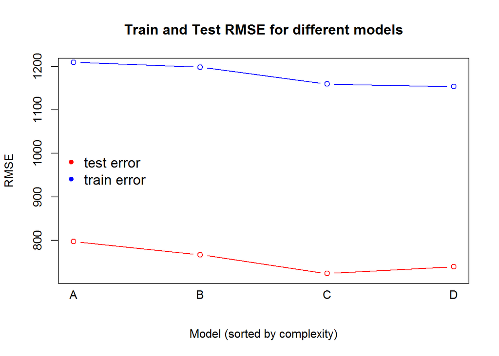

```r
model <- c(1, 2, 3, 4)
test_RMSE <- c(796.8922, 766.715, 723.1573, 739.0976)
train_RMSE <- c(1210, 1199, 1160, 1154)
par(xaxt = "n")
plot(model, test_RMSE, type = "b", ylim = c(720, 1200), col = "red", main = "Train and Test RMSE for different models",
    xlab = "Model (sorted by complexity)", ylab = "RMSE")
lines(model, train_RMSE, type = "b", col = "blue")
lablist.x <- as.vector(c("A", "B", "C", "D"))
axis(1, at = seq(1, 4, by = 1), labels = FALSE)
text(x = seq(1, 4, by = 1), par("usr")[3] - 0.2, labels = lablist.x, pos = 1,
    xpd = TRUE)


legend("left", legend = c("test error", "train error"), pch = 20, col = c("red",
    "blue"), bty = "n", cex = 1.2, box.lty = 0)
```

## Exercise 5&6

The data set describes activity patterns in a social network and is split into the training and test set. The training set contains 16,000 data samples with 16 dimensional input and one-dimensional real-valued target. The test set contains 4,000 samples with only input features, and your task is to predict the output for them.

**Solution:**

I tried to solve this assignment in 2 ways: using linear regression and random forest.

- Random Forest

Random forest is an ensemble learning method that operates by constructing a multitude of decision trees at training time and outputting the class that is the mode of the classes (classification) or mean prediction (regression) of the individual trees. In R we can use the library randomForest/

First we can load the train data and split it (The test data does not contain the target variable so this step is needed for checking the accuracy of the algorithm. The provided test data will be used later).

```r
DataFrame <- fread("C:/Users/Arsovska/Documents/train.csv")
DataFrame$account_age <- as.factor(DataFrame$account_age)
DataFrame$agegroup <- as.factor(DataFrame$agegroup)

# split the data
set.seed(42)
rownames(DataFrame) <- 1:nrow(DataFrame)
rows <- sample(x = 1:nrow(DataFrame), size = 0.7 * nrow(DataFrame))
trainDF <- DataFrame[rows, ]
testDF <- DataFrame[!rownames(DataFrame) %in% rows, ]
```

One of the arguments used in the creation of random trees is mtry which gives the number of variables randomly sampled as candidates at each split. We can find the optimal value using the tuneRF function.

```r
# bestmtry <- tuneRF(DataFrame,DataFrame$target,ntreeTry = 100,nodesize =
# 20,stepFactor = 1.2,improve = 0.01, trace=T,plot=T)
```

```r
# High strength of tree = Low error rate of individual tree classifier

model0 <- randomForest(target ~ ., data = trainDF, mtry = 14, nodesize = 10,
    ntree = 100, type = regression)

model1 <- update(model0, . ~ . - connections)

# Random Forest parameters mtry=number of variables selected at each split
# Lower mtry less correlation between trees(good), decreases strength of
# each tree(bad)
importance(model1)
```

```
##                IncNodePurity
## foreign_conns      1386.6578
## foreign_conns2     2293.7557
## ccf                1561.0190
## conns_new           761.9679
## time               3001.1920
## ccf_old            1298.2178
## account_age        2119.3359
## agegroup           1697.0979
## browserID          1014.6023
## days               2451.6958
## usage1             2072.8658
## usage2             1440.6816
## usage3             5150.9695
## usage4            40136.6609
## usage5             8281.7470
```

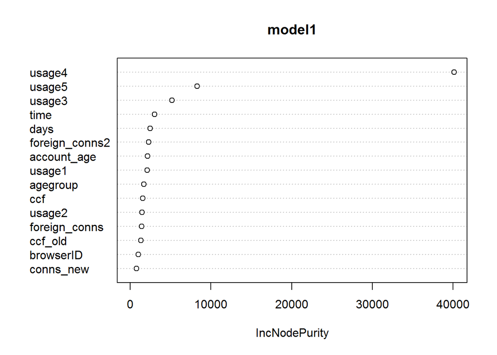

```r
varImpPlot(model1)
```

```r
pred <- predict(model1, testDF, type = "class")
t <- table(predictions = pred, actual = testDF$target)

# accuracy metric
sum(diag(t)/sum(t))
```

```
## [1] 0.000625
```

```r
diffA <- (testDF$target - pred)
RMSEA <- sqrt(mean((diffA)^2))
RMSEA
```

```
## [1] 1.893088
```

Finally we can load the test data and try to predict the target variable.

```r
testDF <- fread("C:/Users/Arsovska/Documents/test.csv")

testDF$account_age <- as.factor(testDF$account_age)
testDF$agegroup <- as.factor(testDF$agegroup)

model0 <- randomForest(target ~ ., data = trainDF, mtry = 14, nodesize = 10,
    ntree = 100, type = regression)

model1 <- update(model0, . ~ . - connections)

pred <- predict(model1, testDF, type = "class")

# write.csv(pred, file = 'MyData.csv')
```

- Linear regression

Using lm we can create a linear model try to predict the target variable. Features with high mutual correlation are excluded from the model. This model explains only 50% from the variance which means we have slightly better results using the random forest.

```r
linearModelAllVar = lm(target ~ conns_new + time + agegroup + browserID + days +
    usage1 + usage3 + usage4 + usage5, data = trainDF)
summary(linearModelAllVar)
```

```
##
## Call:
## lm(formula = target ~ conns_new + time + agegroup + browserID +
##     days + usage1 + usage3 + usage4 + usage5, data = trainDF)
##
## Residuals:
##     Min      1Q  Median      3Q     Max
## -7.8595 -1.1220 -0.5527  0.5337  8.8413
##
## Coefficients:
##               Estimate Std. Error t value Pr(>|t|)
## (Intercept)  1.265e+00  9.325e-02  13.568  < 2e-16 ***
## conns_new    3.764e-02  6.834e-03   5.508 3.70e-08 ***
## time         1.684e-02  4.884e-03   3.448 0.000568 ***
## agegroup1   -9.858e-02  4.471e-02  -2.205 0.027491 *
## agegroup2   -2.305e-01  5.121e-02  -4.501 6.84e-06 ***
## agegroup3   -1.224e-01  8.677e-02  -1.411 0.158307
## browserID    2.238e-05  8.549e-06   2.618 0.008869 **
## days         1.531e-02  3.427e-03   4.467 8.02e-06 ***
## usage1       4.950e-01  1.136e-01   4.357 1.33e-05 ***
## usage3      -4.492e-02  4.148e-03 -10.827  < 2e-16 ***
## usage4       6.870e+00  1.388e-01  49.480  < 2e-16 ***
## usage5       2.010e+00  6.431e-02  31.251  < 2e-16 ***
## ---
## Signif. codes:  0 '***' 0.001 '**' 0.01 '*' 0.05 '.' 0.1 ' ' 1
##
## Residual standard error: 1.95 on 11188 degrees of freedom
## Multiple R-squared:  0.5047, Adjusted R-squared:  0.5042
## F-statistic:  1037 on 11 and 11188 DF,  p-value: < 2.2e-16
```

```r
model1 <- update(linearModelAllVar, . ~ . - connections)
```

## Exercise 7

Try ridge and lasso regressions for model 4 from task 4 and add the resulting RMSE of training and test set on the plot generated in task 4. Explain in general terms what do ridge and lasso regression do. Then interpret the RMSE outcomes.

**Solution:**

When we are dealing with large number of parameters, it is needed to penalize some of them because they should have little effect compared to the others. Ridge and Lasso are regularization techniques that work by penalizing the magnitude of coefficients of features along with minimizing the error between predicted and actual observations.Ridge regression can’t zero out coefficients and we either end up including all the coefficients in the model, or none of them. In contrast, lasso does both parameter shrinkage and variable selection automatically.

Ridge uses L2 regression, where as lasso uses L1. In L2 regression, the penalty is the sum of the squares of the coefficients and for L1, it’s the sum of the absolute values of the coefficients. It’s a shrinkage towards zero using an absolute value (L1 penalty) rather than a sum of squares(L2 penalty).

In R we can calculate this regression using the glmnet package.

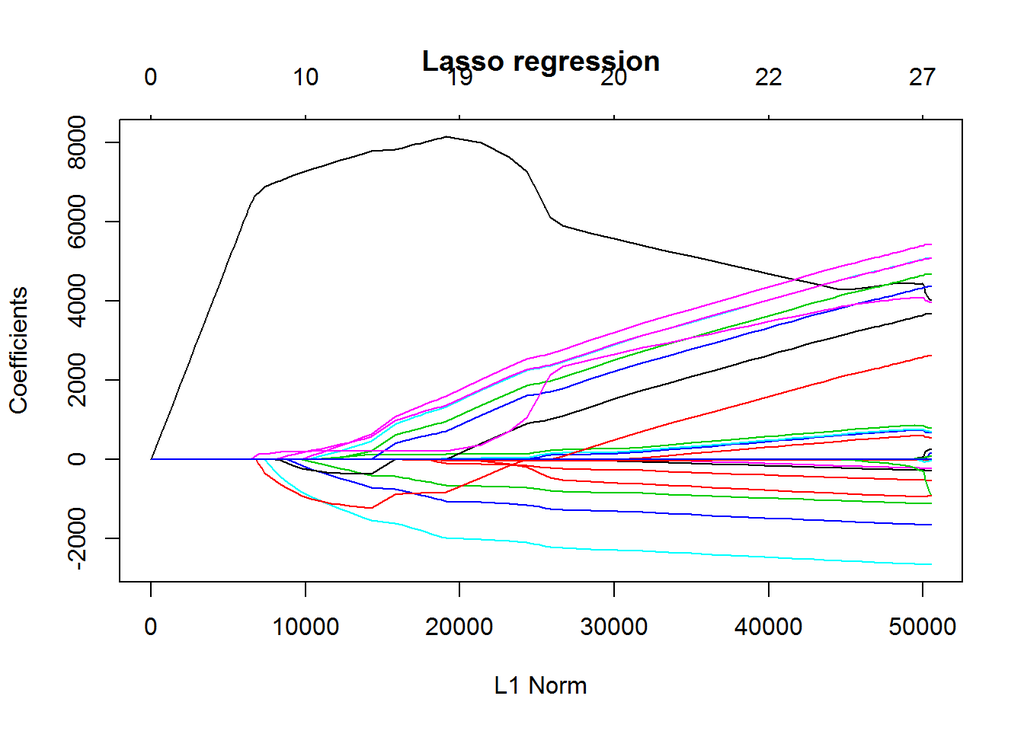

```r
xfactors <- model.matrix(price ~ carat + cut + color + clarity + depth + table +
    x + y + z + CaratSq + DepthSq + Depthcub + Caratcub + xsq + ysq + zsq)[,
    -1]
xx <- as.matrix(data.frame(xfactors))
y <- df.train$price
lasso <- glmnet(xx, y = price, alpha = 1)
plot(lasso, main = "Lasso regression")
```

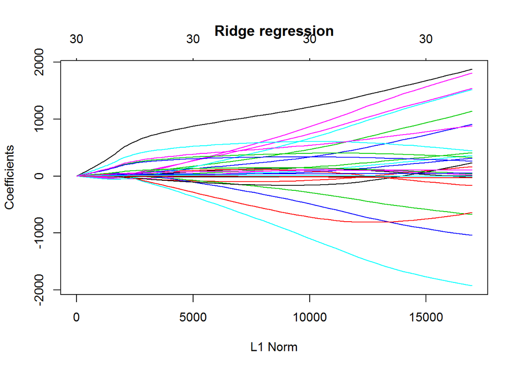

```r
ridge <- glmnet(xx, y = price, alpha = 0)
plot(ridge, main = "Ridge regression")
```

```r
# make predictions Lasso train data
predict_lasso_train <- predict(lasso, xx, type = "link")
# summarize accuracy
mse_lasso_train <- mean((y - predict_lasso_train)^2)
print(sqrt(mse_lasso_train))
```

```
## [1] 1696.819
```

```r
# make predictions Ridge train data
predict_ridge_train <- predict(ridge, xx, type = "link")
# summarize accuracy
mse_ridge_train <- mean((y - predict_ridge_train)^2)
print(sqrt(mse_ridge_train))
```

```
## [1] 3022.178
```

```r
xfac <- model.matrix(price_test ~ carat_test + cut_test + color_test + clarity_test +
    depth_test + table_test + x_test + y_test + z_test + CaratSq_t + DepthSq_t +
    Caratcub_t + Depthcub_t + xsq_t + ysq_t + zsq_t)[, -1]

xx_test <- as.matrix(data.frame(xfac))

# make predictions Lasso test data
predict_lasso_test <- predict(lasso, xx_test, type = "link")
mse_lasso_test <- mean((y_test - predict_lasso_test)^2)

# make predictions Ridge train data
predict_ridge_test <- predict(ridge, xx_test, type = "link")
mse_ridge_test <- mean((y_test - predict_ridge_test)^2)
```

For comparison the values of the RMSE for the train and the test data are added to the previous plot from assignment 4.

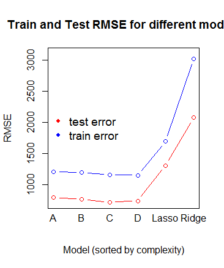